# R-Markdown workshop

# Objectives

- Understand what RMarkdown is and why you should use it
- Learn the basic components of R Markdown
- Learn how to create an RMarkdown file
- Export an RMarkdown file into many file formats
- Understand the value of writing reproducible reports
- Become familiar with R code chunks, and understand their purpose, structure and options
- Become familiar with Markdown language
- Learn about R Notebook

# Understanding Markdown

*What is Markdown?*

- A plain text formatting syntax
  - Like HTML, but easier to write and read
  - Can be written in any text editor.
  - Some text editors can render Markdown documents, but these documents are still readable if you can’t render them.
- Markdown files can be converted to HTML
  - Markdown is a system for writing web pages by marking up the text much as you would in an email rather than writing html code. The marked-up text gets *converted* to html, replacing the marks with the proper html code.

# What is R Markdown?

- R Markdown is a file format for making dynamic documents with R.
- `knitr` allows you to mix basically any type of text with code from different programming languages, but we recommend that you use `R Markdown`, which mixes Markdown with R. [Markdown](https://www.markdownguide.org/) is a light-weight mark-up language for creating web pages.
- Pandoc is a free and open-source document converter

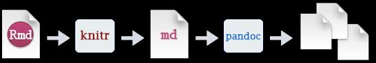

## Why you should use it

Writing long reports with Word can become easily frustrating when you need to format figures or page breaks. Creating a web page (as an html file) using R Markdown makes things easier.

Additionally, the formatting of and R Markdown document is simple and easy to modify, allowing you to spend more time on your analyses instead of writing reports.

# Understand the value of writing reproducible reports

Ideally, as an analysis you would run in a lab, you want your documents to be *reproducible*: If an error is discovered, or if some additional subjects are added to the data, you can just re-compile the report and get the new or corrected results rather than having to reconstruct figures, paste them into a Word document, and hand-edit various detailed results.

This sort of idea has been called “literate programming”.

## Learn how to create an RMarkdown file

Within RStudio, click File → New File → R Markdown and you’ll get a dialog box like this:

[figure not shown]

Screenshot of the New R Markdown file dialogue box in RStudio

Stick with the default (HTML output), as you will learn that it is very easy to change it to another format later. Remember to give a title (this can also be easily changed later in your document).

## Basic components of R Markdown

The initial chunk of text (header) contains instructions for R to specify what kind of document will be created, and the options chosen. You can use the header to give your document a title, author, date, and tell it what type of output you want to produce. In this case, we’re creating an html document.

```
---
title: "Initial R Markdown document"
author: "Karl Broman"
date: "April 23, 2015"
output: html_document
---
```

You can delete any of those fields if you don’t want them included. The double-quotes aren’t strictly *necessary* in this case. They’re mostly needed if you want to include a colon in the title.

RStudio creates the document with some example text to get you started. Note below that there are chunks like

````
  ```{r}
summary(cars)
```
````

These are chunks of R code that will be executed by `knitr` and replaced by their results. More on this later.

## Markdown

For now, let’s delete all of the stuff that’s there and write a bit of markdown.

To create headers, you use `#`:

```
# Header 1
## Header 2
### Header 3...
```

Note that there is no space before the hashtag, but a space after is required.

# A space before the hashtag will not not work

#Neither will no space after it

You make things **bold** using two asterisks, like this: `**bold**`, and you make things *italics* by using underscores, like this: `_italics_`.

You can make a bulleted list by writing a list with hyphens or asterisks, like this:

```
* bold with double-asterisks
* italics with underscores
* code-type font with backticks
```

or like this:

```
- bold with double-asterisks
- italics with underscores
- code-type font with backticks
```

Each will appear as:

- bold with double-asterisks
- italics with underscores
- code-type font with backticks

You can use whatever method you prefer, but *be consistent*. This maintains the readability of your code.

You can make a numbered list by just using numbers. You can even use the same number over and over if you want:

```
1. bold with double-asterisks
1. italics with underscores
1. code-type font with backticks
```

This will appear as:

1. bold with double-asterisks
2. italics with underscores
3. code-type font with backticks

You *compile* the R Markdown document to an html webpage by clicking the “Knit” button in the upper-left.

### Challenge 1

1. Create a new R Markdown document. Delete all of the R code chunks and write a bit of Markdown (some sections, some italicized text, and an itemized list).
2. Convert the document to a webpage.

**Solution to Challenge 1**

In RStudio, select File > New file > R Markdown…

Delete the placeholder text and add the following:

```
 # Header 1

 ## Header 2

 This workshop will **teach you** on

 * Markdown
 * R Markdown
 * R Notebook
 * KnitR
 * And more
```

Then click the ‘Knit’ button on the toolbar to generate an html document (webpage).

## A bit more Markdown

You can make a hyperlink like this: `[text to show](http://the-web-page.com)`.

You can include an image file like this: `![caption](http://url/for/file)`

You can do subscripts (e.g., F<sub>2</sub>) with `F~2~` and superscripts (e.g., F<sup>2</sup>) with `F^2^`.

If you know how to write equations in [LaTeX](http://www.latex-project.org/), you can use `$ $` and `$$ $$` to insert math equations, like `$E = mc^2$` and

```
$$y = \mu + \sum_{i=1}^p \beta_i x_i + \epsilon$$
```

You can review Markdown syntax by navigating to the “Markdown Quick Reference” under the `Help` field in the toolbar at the top of RStudio.

## R code chunks

The real power of Markdown comes from mixing markdown with chunks of code. This is R Markdown. When processed, the R code will be executed; if they produce figures, the figures will be inserted in the final document.

The main code chunks look like this:

````
```{r load_data}
your_data <- read.csv("your_data.csv")
```
````

That is, you place a chunk of R code between `` ```{r chunk_name} `` and `` ``` ``. You should give each chunk a unique name, as they will help you to fix errors and, if any graphs are produced, the file names are based on the name of the code chunk that produced them. You can create code chunks quickly in RStudio using the shortcuts `Ctrl`+`Alt`+`I` on Windows and Linux, or `Cmd`+`Option`+`I` on Mac.

### Challenge 2

Add code chunks to:

- Load the ggplot2 package
- Read the data
- Create a plot
- Convert the file into HTML

**Solution to Challenge 2**

````
 ```{r load-ggplot2}

 library("ggplot2")

 ```
````

````
 ```{r read-gapminder-data}

library(gapminder)

 ```
````

````
 ```{r make-plot}

 plot(lifeExp ~ year, data = gapminder)

 ```
````

## How things get compiled

When you press the “Knit” button, the R Markdown document is processed by [`knitr`](http://yihui.name/knitr) and a plain Markdown document is produced (as well as, potentially, a set of figure files): the R code is executed and replaced by both the input and the output; if figures are produced, links to those figures are included.

The Markdown and figure documents are then processed by the tool [`pandoc`](http://pandoc.org/), which converts the Markdown file into an html file, with the figures embedded.